# Tools and Methods of Data Analysis

## Session 5 - Part 1

Niels Hoppe <niels.hoppe.extern@srh.de>

### Overview of Theoretical Distributions

|  | discrete | continuous |
| --- | --- | --- |
|  | Uniform | Uniform |
|  | Bernoulli |  |
|  | Binomial | Normal |
| Approx. by | Poisson | T |

```python
from scipy import stats

import pandas as pd
import seaborn as sns
```

### Functions of Theoretical Distributions

**Probability mass function**:

the probability that a **discrete** random variable is exactly equal to some value

**Probability density function**:

the probability that a **continuous** variable falls within a particular range of values

**Cumulative distribution function**:

the probability that X will take a value **less than or equal to** some value

**Percent point function**:

the value of a random variable such that the probability of the variable being less than or equal to that value equals the given probability

aka. Quantile Function or Inverse Cumulative Distribution Function

**Random variates**:

Creates a series of values from a chosen distribution

### Comparison between R and Python

By example of binomial distribution and normal distribution

| Concept | R | Python |
| --- | --- | --- |
| Probability mass function | dbinom | stats.binom.pmf |
| Probability density function | dnorm | stats.norm.pdf |
| Cumulative distribution function | pbinom | stats.binom.cdf |
| Percent point function | qbinom | stats.binom.ppf |
| Random variates | rbinom | stats.binom.rvs |

### Discrete distributions

- Discrete uniform distribution
- Bernoulli distribution
- Binomial distribution
- Poisson distribution

See also [Discrete Distributions in `scipy.stats`](https://docs.scipy.org/doc/scipy/tutorial/stats/discrete.html#discrete-distributions-in-scipy-stats)

### Discrete uniform distribution

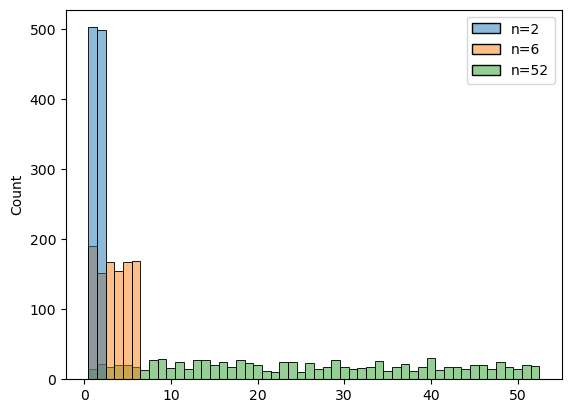

```python
df = pd.DataFrame({
    'n=2': stats.randint.rvs(low=1, high=3, size=1000),
    'n=6': stats.randint.rvs(low=1, high=7, size=1000),
    'n=52': stats.randint.rvs(low=1, high=53, size=1000)
})
sns.histplot(df, discrete=True); None
```

### Discrete uniform distribution (cont.)

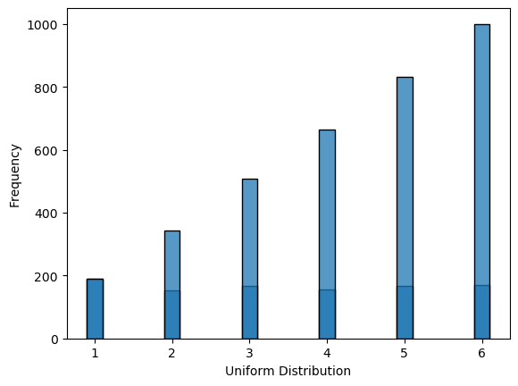

```python
plot = sns.histplot(df['n=6'], discrete=True, shrink=0.2)
sns.histplot(df['n=6'], discrete=True, shrink=0.2, cumulative=True)
plot.set(xlabel='Uniform Distribution', ylabel='Frequency'); None
```

### Bernoulli distribution

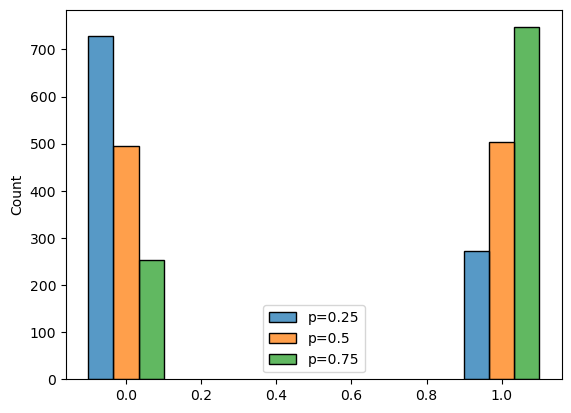

```python
df = pd.DataFrame({
    'p=0.25': stats.bernoulli.rvs(p=0.25, size=1000),
    'p=0.5': stats.bernoulli.rvs(p=0.5, size=1000),
    'p=0.75': stats.bernoulli.rvs(p=0.75, size=1000)
})
sns.histplot(df, discrete=True, shrink=0.2, multiple='dodge'); None
```

### Binomial distribution

Characterized by

- Probability of success $p$ and
- Number of trials $n$

Statistical parameters can be calculated as:

$$\mu = n \cdot p$$$$\sigma^2 = n \cdot p \cdot (1 - p)$$

### Binomial distribution

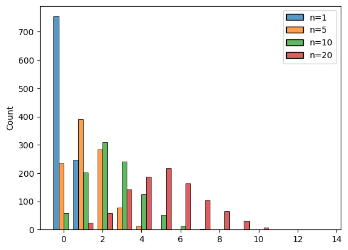

```python
df = pd.DataFrame({
    'n=1': stats.binom.rvs(n=1, p=0.25, size=1000),
    'n=5': stats.binom.rvs(n=5, p=0.25, size=1000),
    'n=10': stats.binom.rvs(n=10, p=0.25, size=1000),
    'n=20': stats.binom.rvs(n=20, p=0.25, size=1000)
})
sns.histplot(df, discrete=True, multiple='dodge'); None
```

### Binomial distribution (cont.)

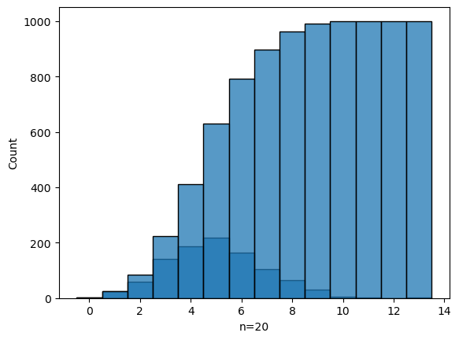

```python
sns.histplot(df['n=20'], discrete=True)
sns.histplot(df['n=20'], discrete=True, cumulative=True); None
```

### Binomial distribution (cont.)

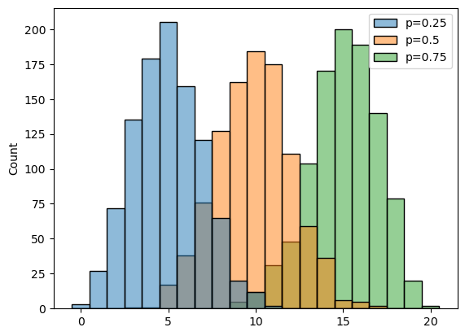

```python
df = pd.DataFrame({
    'p=0.25': stats.binom.rvs(n=20, p=0.25, size=1000),
    'p=0.5': stats.binom.rvs(n=20, p=0.5, size=1000),
    'p=0.75': stats.binom.rvs(n=20, p=0.75, size=1000)
})
sns.histplot(df, discrete=True); None
```

### Poisson distribution

- Discrete distribution
- Large number of possible events, each of which is rare
  - Binomial dist. approaches poisson for large $n$ and small $p$
- Single parameter $\lambda$ or $\mu$: expected value

### Poisson distribution (cont.)

Large number of possible events, each of which is rare, e.g.,

- the number of meteorites greater than 1 meter diameter that strike Earth in a year;
- the number of laser photons hitting a detector in a particular time interval; and
- the number of students achieving a low and high mark in an exam.

### Poisson distribution (cont.)

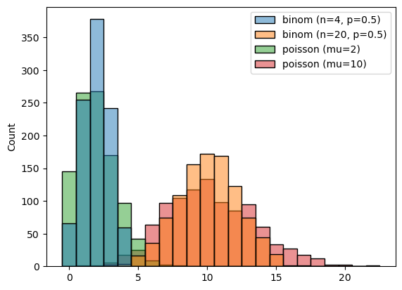

```python
df = pd.DataFrame({
    'binom (n=4, p=0.5)': stats.binom.rvs(n=4, p=0.5, size=1000),
    'binom (n=20, p=0.5)': stats.binom.rvs(n=20, p=0.5, size=1000),
    'poisson (mu=2)': stats.poisson.rvs(mu=2, size=1000),
    'poisson (mu=10)': stats.poisson.rvs(mu=10, size=1000),
})
sns.histplot(df, discrete=True); None
```

### Poisson distribution (cont.)

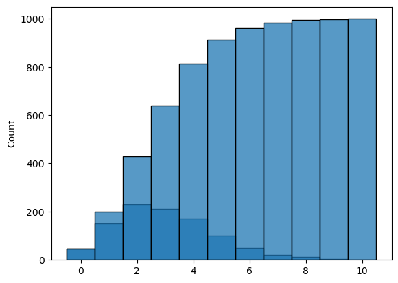

```python
values = stats.poisson.rvs(mu=3, size=1000)
sns.histplot(values, discrete=True)
sns.histplot(values, discrete=True, cumulative=True); None
```

### Continuous distributions

- Continuous uniform distribution
- Normal distribution
- t distribution

See also [Continuous Distributions in `scipy.stats`](https://docs.scipy.org/doc/scipy/tutorial/stats/continuous.html#continuous-distributions-in-scipy-stats)

```python
import matplotlib.pyplot as plt
import numpy as np
```

### Continuous uniform distribution

Characterized by

- lower bound of interval (location) and
- width of interval (scale)

### Continuous uniform distribution (cont.)

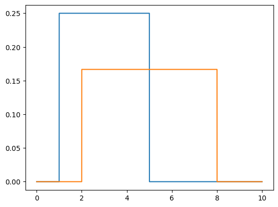

```python
x = np.arange(0, 10, 0.001)
plt.plot(x, stats.uniform.pdf(x, loc=1, scale=4)); None
plt.plot(x, stats.uniform.pdf(x, loc=2, scale=6)); None
```

### Normal distribution

Characterized by

- mean $\mu$ (location) and
- standard deviation $\sigma$ (scale)

See also [Central limit theorem](https://en.wikipedia.org/wiki/Central_limit_theorem)

### Normal distribution (cont.)

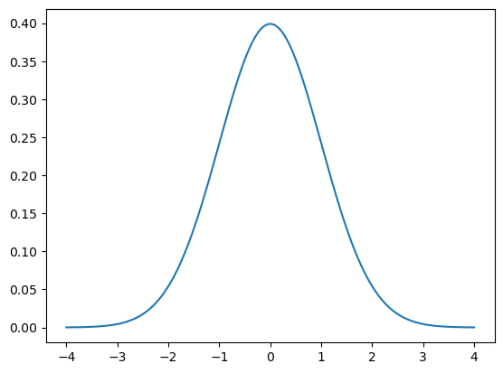

```python
x = np.arange(-4, 4, 0.001)
plt.plot(x, stats.norm.pdf(x, loc=0, scale=1)); None
```

### Normal distribution (cont.)

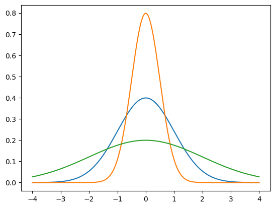

```python
x = np.arange(-4, 4, 0.001)
plt.plot(x, stats.norm.pdf(x, loc=0, scale=1))
plt.plot(x, stats.norm.pdf(x, loc=0, scale=0.5))
plt.plot(x, stats.norm.pdf(x, loc=0, scale=2)); None
```

### Normal distribution (cont.)

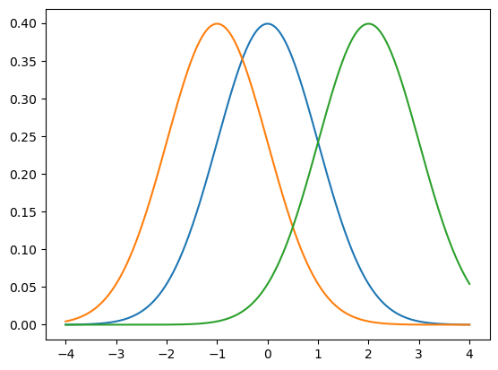

```python
x = np.arange(-4, 4, 0.001)
plt.plot(x, stats.norm.pdf(x, loc=0, scale=1))
plt.plot(x, stats.norm.pdf(x, loc=-1, scale=1))
plt.plot(x, stats.norm.pdf(x, loc=2, scale=1)); None
```

### T distribution

Can be used as an approximation of the normal distribution based on sample size $n$. Characterized by

- degrees of freedom (df): $n - 1$,
- mean $\mu$ (location) and
- standard deviation $\sigma$ (scale)

### T distribution (cont.)

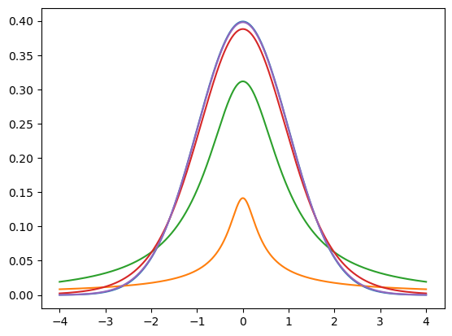

```python
x = np.arange(-4, 4, 0.001)

plt.plot(x, stats.norm.pdf(x))
plt.plot(x, stats.t.pdf(x, df=0.09))
plt.plot(x, stats.t.pdf(x, df=0.9))
plt.plot(x, stats.t.pdf(x, df=9))
plt.plot(x, stats.t.pdf(x, df=99)); None
```